# R Notebook

# Homework

This homework will recap basic time series, time series modelling, and spatial visualisation.

The following libraries are required for thgis study:Y:

```r
library(tidyverse)
library(lubridate)
library(tsibble)
library(tsibbledata)
library(fable)
library(urca)
```

*Question 1: Load in the nyc_bikes data from the tsibbledata package. Have an initial look at it to see what you’re working with. Create three new columns: one that stores only the year the bike was used, one that stores only the month the bike was used, and one that stores the date. Use the data stored in start_time to create these new columns.*

```r
nyc_bikes
class(nyc_bikes)
```

*Question 2: Summarise the number of bike hire counts by month. Make a plot of this data.*

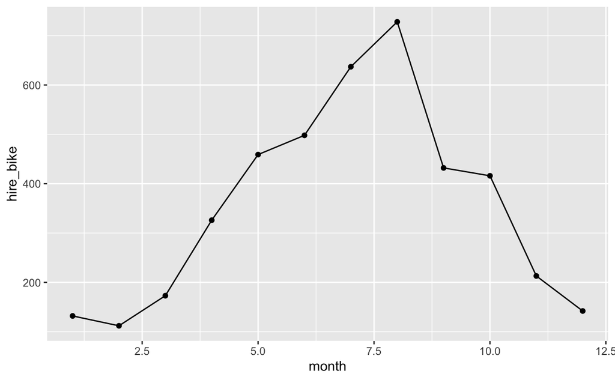

The plot shows the number of bike hire in the New York city, for each month in 2018. The first point corresponds to the month January and the last point corresponds to December. As shown, the number of bike hire increases in the sprimng time and reaches the highest value, around 750, in August. This is expected, as cyclists tend to ride a bike in better weather conditions. Moreover, there is a higher number of tourists during the summer holiday and tourists often use hire bikes. The number of hire-bikes decreases after August. The data from the plot are not sufficient enought in order to predict a behaviour of hire bikes in the next couple of years.

*Question 3: Now Summarise the number of bike hire counts by date. Make a plot of this new aggregated data. What does this plot tell you about the time series? Would this data be preferrable for time series forecasting compared to the monthly data?*

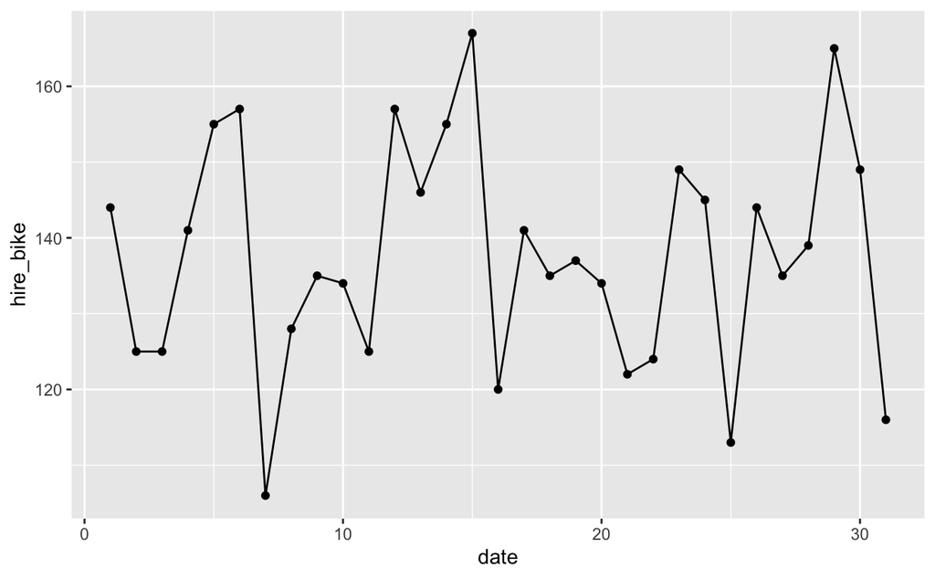

```r
nyc_bikes_by_date %>%
  ggplot()+
  aes(x= date, y = hire_bike) +
  geom_line() +
  geom_point() #+
  xlab("date")
```

```
$x
[1] "date"

attr(,"class")
[1] "labels"
```

**Note, a second figure is also ploted which shows the number of bikes in each individual day.**

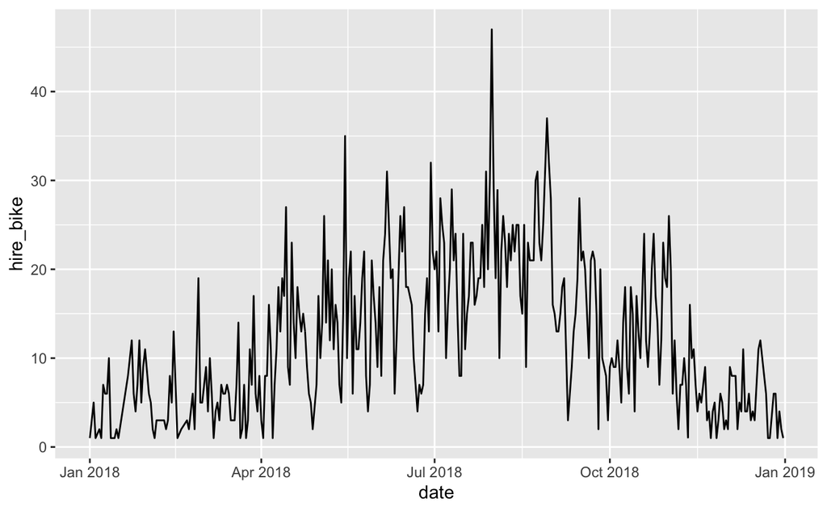

*Question 4: Let’s begin to build a model. For this, we will test the NAIVE, MEAN, and SNAIVE model.*

```r
library(urca)
```

[output not shown]

[output cut: 21 more lines]

[output not shown]

[output cut: 21 more lines]

```r
fit <- nyc_bikes_filled  %>%
  model(
    snaive = SNAIVE(nyc_bikes_filled ),
    mean_model = MEAN(nyc_bikes_filled ),
    arima = ARIMA(nyc_bikes_filled )
  )
```

```
Error: A model specification is trained to a dataset using the `model()` function.
Refer to the documentation in ?model for more details.
```

*Question 5:Now we have our model fit, build a forecast to predict bike use over the next four months. Plot your models alongside your data.*

The code below is forecasting for the next 120 observations (days). Therefore, the forecasting parameter, *h*, is chose to be 120.

```r
forecast_1 <- fit %>%
  fabletools::forecast(h = 120)
forecast_1
```

```r
forecast_1 %>%
  autoplot(nyc_bikes_by_date, level = NULL) +
  ggtitle("Forecasts for New York bike hiring in the next four months") +
  xlab("Month") +
  guides(colour = guide_legend(title = "Forecast"))
```

[output not shown]

*Question 6: Test your model accuracy : choose a training data set from your main dataset, build a forecast on the training set, and then plot the training set forecast against the real data. Calculate model accuracy.*